# Tidying data: extras

## Packages

```r
library(tidyverse)
```

## The pig feed data again

```r
my_url <- "http://ritsokiguess.site/datafiles/pigs1.txt"
pigs <- read_table(my_url)
pigs
```

| pig | feed1 | feed2 | feed3 | feed4 |
| --- | --- | --- | --- | --- |
| 1 | 60.8 | 68.7 | 92.6 | 87.9 |
| 2 | 57.0 | 67.7 | 92.1 | 84.2 |
| 3 | 65.0 | 74.0 | 90.2 | 83.1 |
| 4 | 58.6 | 66.3 | 96.5 | 85.7 |
| 5 | 61.7 | 69.8 | 99.1 | 90.3 |

## Make longer (as before)

```r
pigs %>% pivot_longer(-pig, names_to="feed",
                      values_to="weight") -> pigs_longer
pigs_longer
```

| pig | feed | weight |
| --- | --- | --- |
| 1 | feed1 | 60.8 |
| 1 | feed2 | 68.7 |
| 1 | feed3 | 92.6 |
| 1 | feed4 | 87.9 |
| 2 | feed1 | 57.0 |
| 2 | feed2 | 67.7 |
| 2 | feed3 | 92.1 |
| 2 | feed4 | 84.2 |
| 3 | feed1 | 65.0 |
| 3 | feed2 | 74.0 |

[output cut: 10 more lines]

## Make wider two ways 1/2

`pivot_wider` is inverse of `pivot_longer`:

```r
pigs_longer %>%
  pivot_wider(names_from=feed, values_from=weight)
```

| pig | feed1 | feed2 | feed3 | feed4 |
| --- | --- | --- | --- | --- |
| 1 | 60.8 | 68.7 | 92.6 | 87.9 |
| 2 | 57.0 | 67.7 | 92.1 | 84.2 |
| 3 | 65.0 | 74.0 | 90.2 | 83.1 |
| 4 | 58.6 | 66.3 | 96.5 | 85.7 |
| 5 | 61.7 | 69.8 | 99.1 | 90.3 |

we are back where we started.

## Make wider 2/2

Or

```r
pigs_longer %>%
  pivot_wider(names_from=pig, values_from=weight)
```

| feed | 1 | 2 | 3 | 4 | 5 |
| --- | --- | --- | --- | --- | --- |
| feed1 | 60.8 | 57.0 | 65.0 | 58.6 | 61.7 |
| feed2 | 68.7 | 67.7 | 74.0 | 66.3 | 69.8 |
| feed3 | 92.6 | 92.1 | 90.2 | 96.5 | 99.1 |
| feed4 | 87.9 | 84.2 | 83.1 | 85.7 | 90.3 |

but:

```r
pigs_longer %>%
  pivot_wider(names_from=pig, values_from=weight) %>%
  select(2)
```

| 1 |
| --- |
| 60.8 |
| 68.7 |
| 92.6 |
| 87.9 |

this has selected the column called *1*, which is the column *numbered* 2.

To get the column we want:

```r
pigs_longer %>%
  pivot_wider(names_from=pig, values_from=weight) %>%
  select(`2`)
```

| 2 |
| --- |
| 57.0 |
| 67.7 |
| 92.1 |
| 84.2 |

## Disease presence and absence at two locations

Frequencies of plants observed with and without disease at two locations:

```
Species     Disease present         Disease absent
       Location X Location Y  Location X Location Y
A            44         12          38        10
B            28         22          20        18
```

This has two rows of headers, so I rewrote the data file:

```
Species  present_x present_y    absent_x  absent_y
A            44         12          38        10
B            28         22          20        18
```

## Read in

… into data frame called `prevalence`:

```r
my_url <- "http://ritsokiguess.site/STAC32/disease.txt"
prevalence <- read_table(my_url)
prevalence
```

| Species | present_x | present_y | absent_x | absent_y |
| --- | --- | --- | --- | --- |
| A | 44 | 12 | 38 | 10 |
| B | 28 | 22 | 20 | 18 |

## Lengthen and separate

```r
prevalence %>%
  pivot_longer(-Species, names_to = "column",
               values_to = "freq") %>%
  separate_wider_delim(column, "_",
                       names = c("disease", "location"))
```

| Species | disease | location | freq |
| --- | --- | --- | --- |
| A | present | x | 44 |
| A | present | y | 12 |
| A | absent | x | 38 |
| A | absent | y | 10 |
| B | present | x | 28 |
| B | present | y | 22 |
| B | absent | x | 20 |
| B | absent | y | 18 |

## Making longer, the better way

```r
prevalence %>%
  pivot_longer(-Species, names_to=c("disease", "location"),
               names_sep="_",
               values_to="frequency") -> prevalence_longer
prevalence_longer
```

| Species | disease | location | frequency |
| --- | --- | --- | --- |
| A | present | x | 44 |
| A | present | y | 12 |
| A | absent | x | 38 |
| A | absent | y | 10 |
| B | present | x | 28 |
| B | present | y | 22 |
| B | absent | x | 20 |
| B | absent | y | 18 |

## Making wider, different ways 1/2

```r
prevalence_longer %>%
  pivot_wider(names_from=c(Species, location),
              values_from=frequency)
```

| disease | A_x | A_y | B_x | B_y |
| --- | --- | --- | --- | --- |
| present | 44 | 12 | 28 | 22 |
| absent | 38 | 10 | 20 | 18 |

## Making wider, different ways 2/2

```r
prevalence_longer %>%
  pivot_wider(names_from=location, values_from=frequency)
```

| Species | disease | x | y |
| --- | --- | --- | --- |
| A | present | 44 | 12 |
| A | absent | 38 | 10 |
| B | present | 28 | 22 |
| B | absent | 20 | 18 |

## Interlude

Pigs data again:

```r
pigs_longer %>%
  group_by(feed) %>%
  summarize(weight_mean=mean(weight))
```

| feed | weight_mean |
| --- | --- |
| feed1 | 60.62 |
| feed2 | 69.30 |
| feed3 | 94.10 |
| feed4 | 86.24 |

## What if summary is more than one number?

eg. quartiles:

```r
pigs_longer %>%
  group_by(feed) %>%
  summarize(r = quantile(weight, c(0.25, 0.75)))
```

```
Warning: Returning more (or less) than 1 row per `summarise()` group was deprecated in
dplyr 1.1.0.
ℹ Please use `reframe()` instead.
ℹ When switching from `summarise()` to `reframe()`, remember that `reframe()`
  always returns an ungrouped data frame and adjust accordingly.
```

| feed | r |
| --- | --- |
| feed1 | 58.6 |
| feed1 | 61.7 |
| feed2 | 67.7 |
| feed2 | 69.8 |
| feed3 | 92.1 |
| feed3 | 96.5 |
| feed4 | 84.2 |
| feed4 | 87.9 |

## Following the hint (gives no warning)

```r
pigs_longer %>%
  group_by(feed) %>%
  reframe(r=quantile(weight, c(0.25, 0.75)))
```

| feed | r |
| --- | --- |
| feed1 | 58.6 |
| feed1 | 61.7 |
| feed2 | 67.7 |
| feed2 | 69.8 |
| feed3 | 92.1 |
| feed3 | 96.5 |
| feed4 | 84.2 |
| feed4 | 87.9 |

## this also works

```r
pigs_longer %>%
  group_by(feed) %>%
  summarize(r=list(quantile(weight, c(0.25, 0.75)))) %>%
  unnest(r)
```

| feed | r |
| --- | --- |
| feed1 | 58.6 |
| feed1 | 61.7 |
| feed2 | 67.7 |
| feed2 | 69.8 |
| feed3 | 92.1 |
| feed3 | 96.5 |
| feed4 | 84.2 |
| feed4 | 87.9 |

## Or, even better, use `enframe`:

```r
quantile(pigs_longer$weight, c(0.25, 0.75))
```

```
   25%    75%
65.975 90.225
```

```r
enframe(quantile(pigs_longer$weight, c(0.25, 0.75)))
```

| name | value |
| --- | --- |
| 25% | 65.975 |
| 75% | 90.225 |

## A nice look

Run this one line at a time to see how it works:

```r
pigs_longer %>%
  group_by(feed) %>%
  summarize(r=list(enframe(quantile(weight, c(0.25, 0.75))))) %>%
  unnest(r) %>%
  pivot_wider(names_from=name, values_from=value) -> d
d
```

| feed | 25% | 75% |
| --- | --- | --- |
| feed1 | 58.6 | 61.7 |
| feed2 | 67.7 | 69.8 |
| feed3 | 92.1 | 96.5 |
| feed4 | 84.2 | 87.9 |

## A hairy one

18 people receive one of three treatments. At 3 different times (pre, post, followup) two variables `y` and `z` are measured on each person:

```r
my_url <- "http://ritsokiguess.site/STAC32/repmes.txt"
repmes0 <- read_table(my_url)
repmes0
```

| treatment | rep | pre_y | post_y | fu_y | pre_z | post_z | fu_z |
| --- | --- | --- | --- | --- | --- | --- | --- |
| A | 1 | 3 | 13 | 9 | 0 | 0 | 9 |
| A | 2 | 0 | 14 | 10 | 6 | 6 | 3 |
| A | 3 | 4 | 6 | 17 | 8 | 2 | 6 |
| A | 4 | 7 | 7 | 13 | 7 | 6 | 4 |
| A | 5 | 3 | 12 | 11 | 6 | 12 | 6 |
| A | 6 | 10 | 14 | 8 | 13 | 3 | 8 |
| B | 1 | 9 | 11 | 17 | 8 | 11 | 27 |
| B | 2 | 4 | 16 | 13 | 9 | 3 | 26 |
| B | 3 | 8 | 10 | 9 | 12 | 0 | 18 |
| B | 4 | 5 | 9 | 13 | 3 | 0 | 14 |

[output cut: 8 more lines]

## Create unique ids

```r
repmes0 %>% mutate(id=str_c(treatment, ".", rep)) %>%
  select(-rep) %>%
  select(id, everything()) -> repmes
repmes
```

| id | treatment | pre_y | post_y | fu_y | pre_z | post_z | fu_z |
| --- | --- | --- | --- | --- | --- | --- | --- |
| A.1 | A | 3 | 13 | 9 | 0 | 0 | 9 |
| A.2 | A | 0 | 14 | 10 | 6 | 6 | 3 |
| A.3 | A | 4 | 6 | 17 | 8 | 2 | 6 |
| A.4 | A | 7 | 7 | 13 | 7 | 6 | 4 |
| A.5 | A | 3 | 12 | 11 | 6 | 12 | 6 |
| A.6 | A | 10 | 14 | 8 | 13 | 3 | 8 |
| B.1 | B | 9 | 11 | 17 | 8 | 11 | 27 |
| B.2 | B | 4 | 16 | 13 | 9 | 3 | 26 |
| B.3 | B | 8 | 10 | 9 | 12 | 0 | 18 |
| B.4 | B | 5 | 9 | 13 | 3 | 0 | 14 |

[output cut: 8 more lines]

## Attempt 1

```r
repmes %>% pivot_longer(contains("_"),
                        names_to=c("time", "var"),
                        names_sep="_",
                        values_to = "vvv"
                         )
```

| id | treatment | time | var | vvv |
| --- | --- | --- | --- | --- |
| A.1 | A | pre | y | 3 |
| A.1 | A | post | y | 13 |
| A.1 | A | fu | y | 9 |
| A.1 | A | pre | z | 0 |
| A.1 | A | post | z | 0 |
| A.1 | A | fu | z | 9 |
| A.2 | A | pre | y | 0 |
| A.2 | A | post | y | 14 |
| A.2 | A | fu | y | 10 |
| A.2 | A | pre | z | 6 |

[output cut: 98 more lines]

## Comment

This is *too* long! We wanted a column called `y` and a column called `z`, but they have been pivoted-longer too.

## Attempt 2

```r
repmes %>% pivot_longer(contains("_"),
                        names_to=c("time", ".value"),
                        names_sep="_"
                        ) -> repmes3
repmes3
```

| id | treatment | time | y | z |
| --- | --- | --- | --- | --- |
| A.1 | A | pre | 3 | 0 |
| A.1 | A | post | 13 | 0 |
| A.1 | A | fu | 9 | 9 |
| A.2 | A | pre | 0 | 6 |
| A.2 | A | post | 14 | 6 |
| A.2 | A | fu | 10 | 3 |
| A.3 | A | pre | 4 | 8 |
| A.3 | A | post | 6 | 2 |
| A.3 | A | fu | 17 | 6 |
| A.4 | A | pre | 7 | 7 |

[output cut: 44 more lines]

## Comment

This has done what we wanted.

## Make a graph

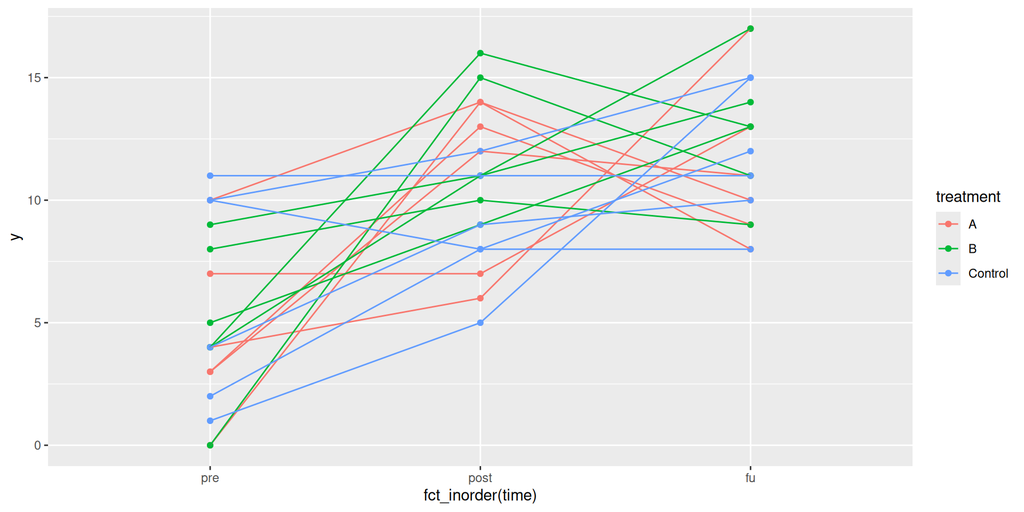

```r
ggplot(repmes3, aes(x=fct_inorder(time), y=y,
                    colour=treatment, group = id)) +
  geom_point() + geom_line()
```

## Comment

- A so-called “spaghetti plot”:
  - The three measurements for each person are joined by lines
  - The lines are coloured by treatment.

## Or do the plot with means

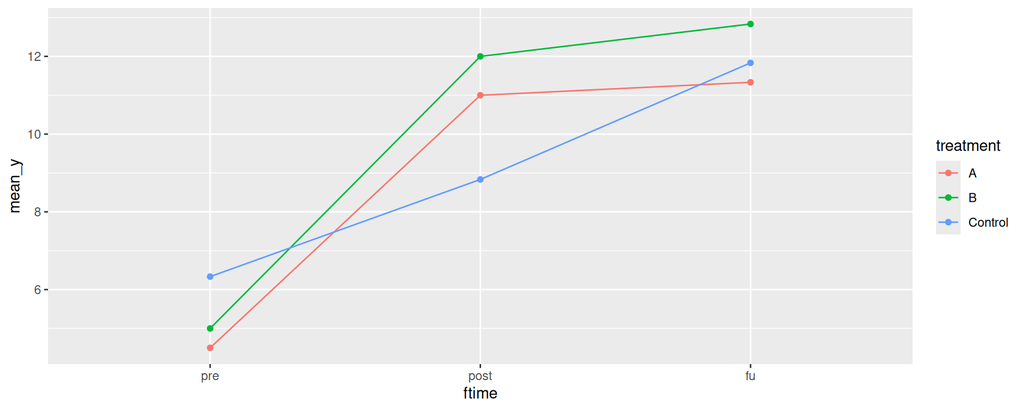

```r
repmes3 %>% group_by(treatment, ftime=fct_inorder(time)) %>%
  summarize(mean_y=mean(y)) %>%
  ggplot(aes(x=ftime, y=mean_y, colour=treatment, group=treatment)) +
    geom_point() + geom_line()
```